# Probability

Shammunul Islam

September 27, 2018

### Probability theory

In probability theory, an experiment or trial (see below) is any procedure that can be infinitely repeated and has a well-defined set of possible outcomes, known as the sample space.[1] An experiment is said to be random if it has more than one possible outcome, and deterministic if it has only one. A random experiment that has exactly two (mutually exclusive) possible outcomes is known as a Bernoulli trial (from Wikipedia).

A Bernoulli random variable has two possible outcomes: 0 or 1. A binomial distribution is the sum of independent and identically distributed Bernoulli random variables.

An event is a set of outcomes of an experiment (a subset of the sample space) to which a probability is assigned

### Binomial distribution in R

**rbinom(number of draws, number of coins in each draw, probability of head)**

#### Bernoulli

Let’s flip a coin once

```r
set.seed(111)
rbinom(1, 1, 0.5)
```

```
## [1] 1
```

#### Binomial

```r
set.seed(123)
rbinom(10, 1, 0.5)
```

```
##  [1] 0 1 0 1 1 0 1 1 1 0
```

```r
set.seed(123)
rbinom(10, 10, 0.5)
```

```
##  [1] 4 6 5 7 7 2 5 7 5 5
```

### Density

It is the probability of getting a specified number of success in a number of events with a specified probability of success.

What is the probability of getting 2 heads in 5 flips with a probability of 0.5?

```r
results = rbinom(100000, 5, 0.5)
mean(results == 2)
```

```
## [1] 0.31472
```

Or, we can use

**dbinom(the outcome for which we are calculating density, number of coins, probability of success)**

```r
dbinom(2, 5, 0.5)
```

```
## [1] 0.3125
```

```r
outcomes = rbinom(10000, 20, 0.5)
mean(outcomes<=4)
```

```
## [1] 0.0055
```

```r
pbinom(5, 20, 0.5)
```

```
## [1] 0.02069473
```

#### If we flip twenty coins with 50% probability of success, what is the probability of at least 4 heads?

```r
1 - pbinom(3, 20, 0.5)
```

```
## [1] 0.9987116
```

### Normal distribution

As we flip more and more, we approximate towards normal distribution.

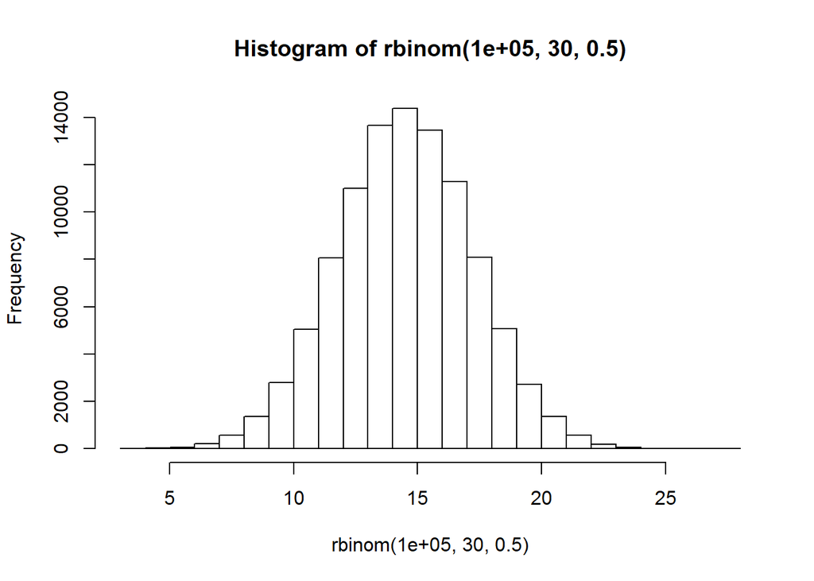

```r
hist(rbinom(100000, 30, 0.5))
```

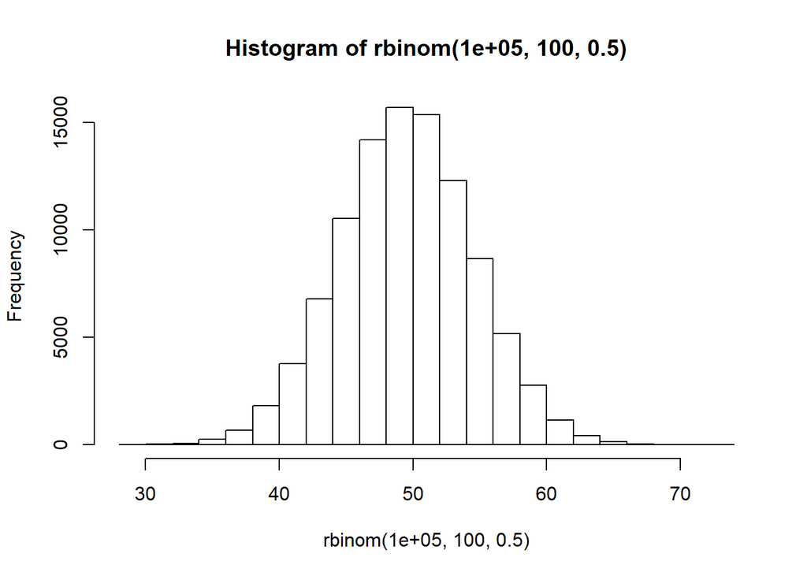

```r
hist(rbinom(100000, 100, 0.5))
```

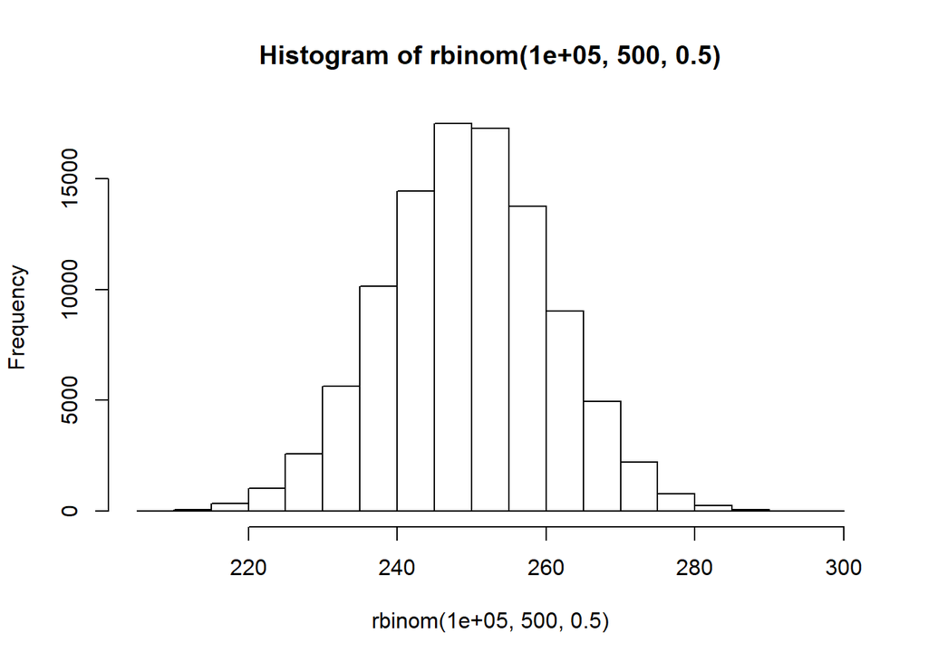

```r
hist(rbinom(100000, 500, 0.5))
```

When we draw from binomial with a very large size, the result looks more and more like a normal distribution.

### Normal approximation to binomial

mu = size.p sigma^2 = size * p * (1 - p)

**rnorm(Number of iteration, mu, sigma)**

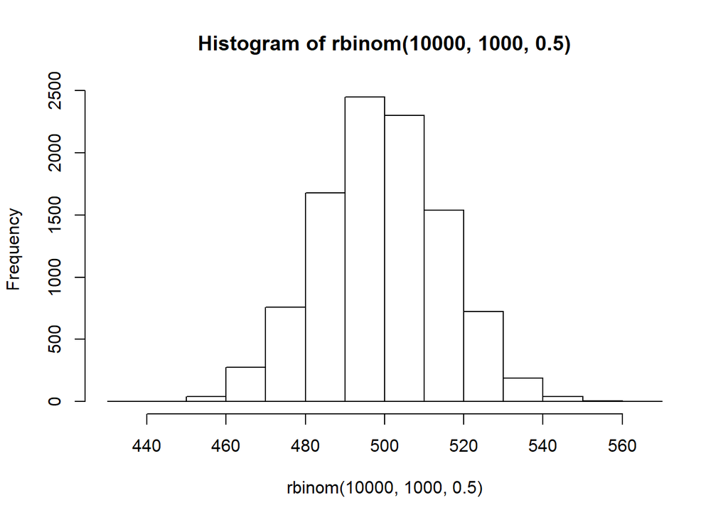

```r
#rnorm(10000, 1000, 0.5)
mu = 1000 * 0.5
sigma_2 = 1000 * 0.5 * 0.5
std = sqrt(sigma_2)
hist(rbinom(10000, 1000, 0.5))
```

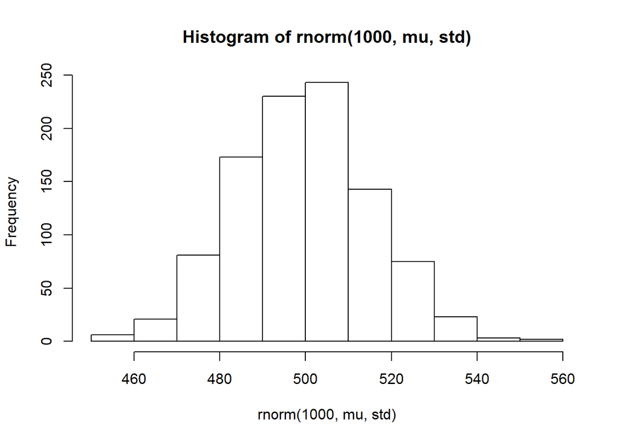

```r
hist(rnorm(1000, mu, std))
```

### Task: Approximate the binomial by Normal distribution

### Poisson distribution – Large n and samll p, good for modeling rare events

```r
data = rbinom(100000, 1000, 1/1000)
```

Or,

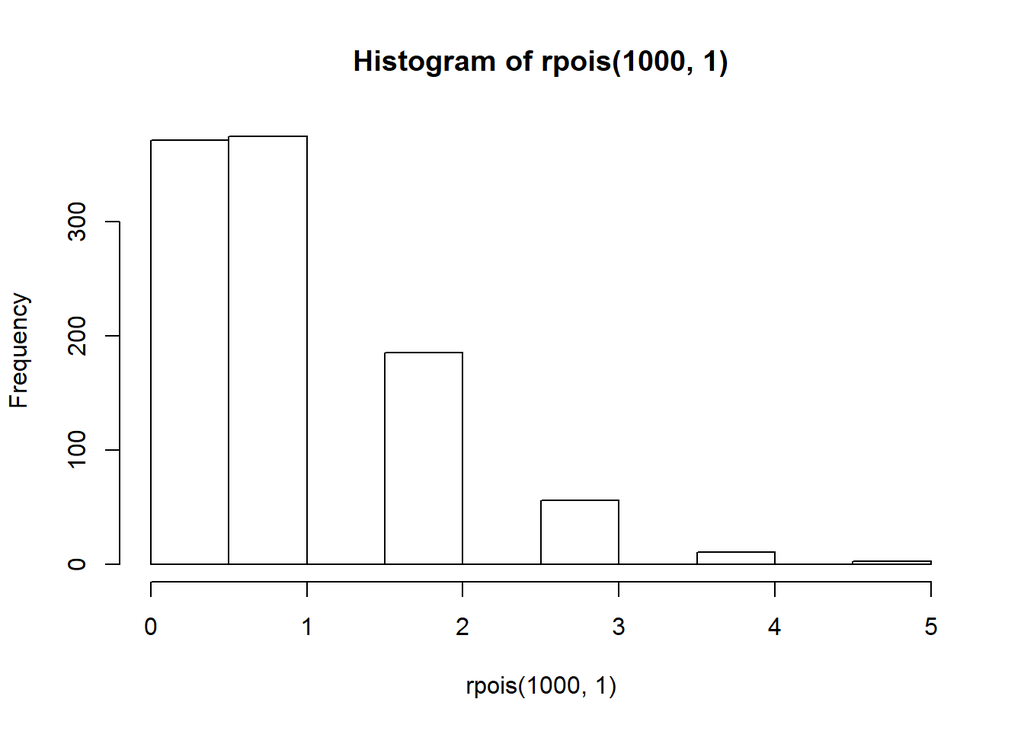

```r
hist(rpois(1000, 1))
```